# Fragile Families - Epigenome wide association study

# 2 Cross sectional epigenome wide association study: Children Age 9

```r
#filter betaqc to child samples only
beta_c <-betaqc[, colnames(betaqc) %in% child_nosmoke$MethID]#; rm(betaqc)
#make sure that the order of the samples matches in the metadata matrix and the beta matrix are ordered the same
child_nosmoke<-child_nosmoke[match(colnames(beta_c), child_nosmoke$MethID), ]
#checks
if(dim(beta_c)[2]!=dim(child_nosmoke)[1]){print('STOP: Sample #s do not match')}
if(identical(colnames(beta_c), child_nosmoke$MethID)==FALSE){print('STOP: Sample names do not match')}
```

```r
#model 1: make model matrix
mod1=model.matrix(~factor(child_nosmoke$smkPreg_binary)+child_nosmoke$global_PC1+child_nosmoke$global_PC2+factor(child_nosmoke$cm1bsex)+child_nosmoke$cm1inpov+child_nosmoke$ChildAgeComposite+child_nosmoke$Epi+child_nosmoke$IC)

#run EWAS with empirical st bayes approach to reduce standard error
out<-lmFit(beta_c, mod1)
out<-eBayes(out)
saveRDS(out, file=file.path(limma.out.dir, 'limmaModel1.Rda'))

#pull out top hits
child.ss.hits<-topTable(out, coef=2, number=nrow(beta_c), confint = T)
rm(mod1, out)

# Annotate top hits
child.m1.ss.hits.annotated <- add_annotations(child.ss.hits)
saveRDS(child.m1.ss.hits.annotated, file=file.path(limma.out.dir, 'Model1TopHits.Rda'))
```

```r
child.m1.ss.hits.annotated <-readRDS(file=file.path(limma.out.dir, 'Model1TopHits.Rda'))
```

```r
#model 2: make model matrix
mod2=model.matrix(~factor(child_nosmoke$smkPreg_binary)+child_nosmoke$global_PC1+child_nosmoke$global_PC2+factor(child_nosmoke$cm1bsex)+child_nosmoke$cm1inpov+child_nosmoke$ChildAgeComposite+child_nosmoke$Epi+child_nosmoke$IC+factor(child_nosmoke$m1g2_YesNoPreg)+factor(child_nosmoke$m1g3_YesNoPreg))

#run EWAS with empirical st bayes approach to reduce standard error
out<-lmFit(beta_c, mod2)
out<-eBayes(out)
saveRDS(out, file=file.path(limma.out.dir, 'limmaModel2.Rda'))

#pull out top hits
child.ss.hits<-topTable(out, coef=2, number=nrow(beta_c))
rm(mod2, out)

#annotate
child.m2.ss.hits.annotated <- add_annotations(child.ss.hits)
saveRDS(child.m2.ss.hits.annotated, file=file.path(limma.out.dir, 'Model2TopHits.Rda'))
```

```r
child.m2.ss.hits.annotated <-readRDS(file=file.path(limma.out.dir, 'Model2TopHits.Rda'))
```

```r
#model 3: make model matrix
mod3=model.matrix(~factor(child_nosmoke$smkPreg_binary)+child_nosmoke$global_PC1+child_nosmoke$global_PC2+factor(child_nosmoke$cm1bsex)+child_nosmoke$cm1inpov+child_nosmoke$ChildAgeComposite+child_nosmoke$Epi+child_nosmoke$IC+factor(child_nosmoke$m1g2_YesNoPreg)+factor(child_nosmoke$m1g3_YesNoPreg)+factor(child_nosmoke$PostnatalMaternalSmokingAny)+factor(child_nosmoke$SmkAtVisitPastmonth))

#run EWAS with empirical st bayes approach to reduce standard error
out<-lmFit(beta_c, mod3)
out<-eBayes(out)
saveRDS(out, file=file.path(limma.out.dir, 'limmaModel3.Rda'))
#pull out top hits
child.ss.hits<-topTable(out, coef=2, number=nrow(beta_c))
rm(mod3, out)


#annotate
child.m3.ss.hits.annotated <- add_annotations(child.ss.hits)
saveRDS(child.m3.ss.hits.annotated, file=file.path(limma.out.dir, 'Model3TopHits.Rda'))
```

```r
child.m3.ss.hits.annotated <-readRDS(file=file.path(limma.out.dir, 'Model3TopHits.Rda'))
```

### 2.0.1 Future analysis: compare top CpGs when run in ancestry specific models

## 2.1 QQ plots

```r
calcLambda<-function(df){
  o<- -log10(sort(df$P.Value, decreasing = F))
  e<- -log10(ppoints(length(df$P.Value)))
  lambda<-median(o)/median(e)
  return(lambda)
}

l_c1<-calcLambda(child.m1.ss.hits.annotated)
l_c2<-calcLambda(child.m2.ss.hits.annotated)
l_c3<-calcLambda(child.m3.ss.hits.annotated)
```

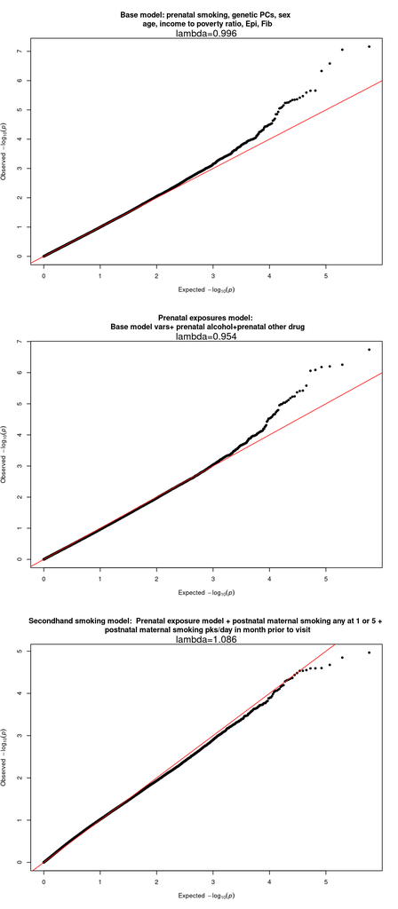

```r
par(mfrow=c(3, 1), mar=c(5.1, 4.1, 5.1, 2.1))
qq(child.m1.ss.hits.annotated$P.Value, main='Base model: prenatal smoking, genetic PCs, sex \n age, income to poverty ratio, Epi, Fib')
mtext(paste0(expression(lambda), '=', round(l_c1, 3)), side=3)
qq(child.m2.ss.hits.annotated$P.Value, main='Prenatal exposures model: \n Base model vars+ prenatal alcohol+prenatal other drug')
mtext(paste0(expression(lambda), '=', round(l_c2, 3)), side=3)
qq(child.m3.ss.hits.annotated$P.Value, main='Secondhand smoking model:  Prenatal exposure model + postnatal maternal smoking any at 1 or 5 + \n postnatal maternal smoking pks/day in month prior to visit')
mtext(paste0(expression(lambda), '=', round(l_c3, 3)), side=3)
```

## 2.2 Manhattan plot

```r
makeManhattan<-function(ss.hits, beta){
  pos.ss <- pos[match(rownames(ss.hits), rownames(beta))]
  chr.ss <- chrnames[match(rownames(ss.hits), rownames(beta))]
  chr.ss.num <- as.numeric(unlist(lapply(chr.ss, function(x) {
    strsplit(x, "chr", fixed = TRUE)[[1]][2]
  })))

  # Construct data frame for function
  formanhattan <- data.frame(pos.ss, chr.ss.num, ss.hits$P.Value)
  colnames(formanhattan) <- c("BP", "CHR", "P")

  formanhattan <- formanhattan[-which(is.na(formanhattan$CHR)), ]
  return(formanhattan)
}

m1.forman<-makeManhattan(child.m1.ss.hits.annotated, beta_c)
m2.forman<-makeManhattan(child.m2.ss.hits.annotated, beta_c)
m3.forman<-makeManhattan(child.m3.ss.hits.annotated, beta_c)
```

### 2.2.1 Manhattan in children (Age 9) model 1

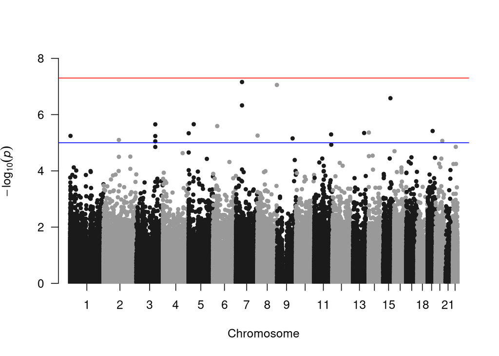

```r
manhattan(m1.forman)
```

## 2.3 Beta vs Beta plots within Age 9 models

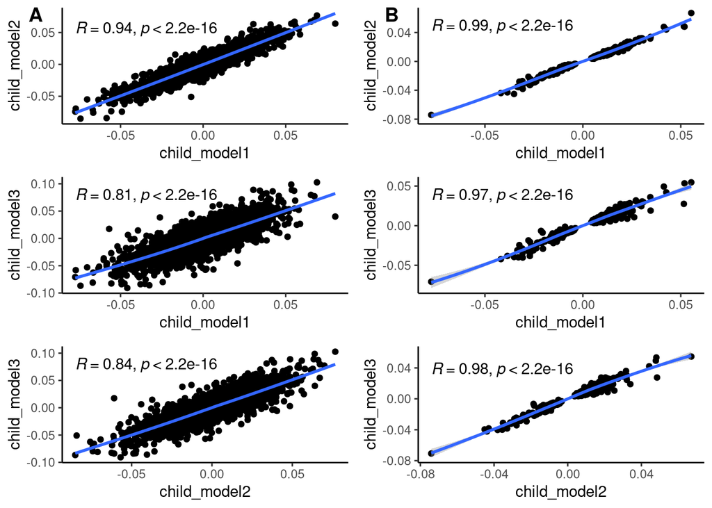

Correlation between effect estimates from the three different epigenome wide linear models in children for A) all CpGs and B) significant CpGs only

```r
child_models<-list('child_model1'=child.m1.ss.hits.annotated, 'child_model2'=child.m2.ss.hits.annotated, 'child_model3'=child.m3.ss.hits.annotated)%>%lapply(., function(x) rownames_to_column(x, var='CpG'))%>%Map(cbind, ., ModelType=names(.))

beta_child<-lapply(child_models, function(x) x %>%dplyr::select(CpG, logFC, ModelType)%>%pivot_wider(id_cols = CpG, values_from=logFC, names_from=ModelType))%>%purrr::reduce(left_join, by='CpG')

#bind_rows(.id='ModelType')%>%mutate('Model'=gsub('.*_', '', ModelType), 'Age'=gsub('_.*', '', ModelType))

sig_beta_m1<-child_models[[1]]%>%filter(P.Value<1e-3)%>%pull(CpG)#change this to 1

smooth_betas<-function(df, x, y){
  x<-enquo(x); y<-enquo(y)
  ggplot(df, aes(x=!!x, y=!!y))+
    geom_point()+geom_smooth()+
    stat_cor()+theme_classic()+
    scale_y_continuous(name=paste0(quo_name(y)))+
    scale_x_continuous(name=paste0(quo_name(x)))
}

a<-smooth_betas(beta_child, child_model1, child_model2)
b<-smooth_betas(beta_child, child_model1, child_model3)
c<-smooth_betas(beta_child, child_model2, child_model3)

d<-smooth_betas(beta_child%>%filter(CpG %in% sig_beta_m1), child_model1, child_model2)
e<-smooth_betas(beta_child%>%filter(CpG %in% sig_beta_m1), child_model1, child_model3)
f<-smooth_betas(beta_child%>%filter(CpG %in% sig_beta_m1), child_model2, child_model3)

all_beta<-plot_grid(a, b, c, ncol=1)
sig_beta<-plot_grid(d, e, f, ncol=1)
plot_grid(all_beta, sig_beta, ncol=2, labels=c('A', 'B'), hjust = -2)
```

## 2.4 Table of top hits in children models

### 2.4.1 Model 1

```r
child.m1.ss.hits.annotated%>% dplyr::rename(Beta.Coefficient=logFC, Average.Methylation=AveExpr)%>% head(n=10)%>%kable()%>%kable_classic()%>%scroll_box(width='100%', height='400px')
```

|  | Beta.Coefficient | CI.L | CI.R | Average.Methylation | t | P.Value | adj.P.Val | B | chr | pos | island | gene | regulatory_feature |
| --- | --- | --- | --- | --- | --- | --- | --- | --- | --- | --- | --- | --- | --- |
| cg04180046 | 0.0346070 | 0.0221414 | 0.0470727 | 0.3599273 | 5.450435 | 1.0e-07 | 0.0128728 | 6.218188 | chr7 | 45002736 | Island | MYO1G | Gene_Associated_Cell_type_specific |
| cg07387044 | -0.0418478 | -0.0570465 | -0.0266492 | 0.9283434 | -5.405683 | 1.0e-07 | 0.0128728 | 5.984669 | chr8 | 145170347 | Island | KIAA1875 |  |
| cg05549655 | 0.0197138 | 0.0122702 | 0.0271575 | 0.1929814 | 5.199547 | 3.0e-07 | 0.0254442 | 4.932014 | chr15 | 75019143 | Island | CYP1A1 | Unclassified_Cell_type_specific |
| cg12803068 | 0.0515825 | 0.0316673 | 0.0714978 | 0.5777704 | 5.085092 | 5.0e-07 | 0.0343453 | 4.363923 | chr7 | 45002919 | S_Shore | MYO1G | Gene_Associated_Cell_type_specific |
| cg05730365 | 0.0166469 | 0.0098003 | 0.0234934 | 0.0326521 | 4.773552 | 2.2e-06 | 0.1057868 | 2.877406 | chr5 | 37838563 | Island | GDNF |  |
| cg21370924 | 0.0212122 | 0.0124844 | 0.0299400 | 0.4274124 | 4.771571 | 2.2e-06 | 0.1057868 | 2.868238 | chr3 | 141087313 | OpenSea | ZBTB38 |  |
| cg04621664 | 0.0155941 | 0.0091376 | 0.0220507 | 0.0469792 | 4.741790 | 2.6e-06 | 0.1057868 | 2.730796 | chr6 | 31802874 | S_Shore | C6orf48;C6orf48;C6orf48;SNORD48;C6orf48 | Promoter_Associated |
| cg07652272 | 0.0413617 | 0.0240214 | 0.0587020 | 0.0387283 | 4.682993 | 3.4e-06 | 0.1057868 | 2.461825 | chrX | 2847510 | Island | ARSD;ARSD |  |
| cg17107893 | 0.0113013 | 0.0065371 | 0.0160655 | 0.2551392 | 4.657175 | 3.8e-06 | 0.1057868 | 2.344718 | chr19 | 36912880 | Island |  |  |
| cg16304521 | 0.0149833 | 0.0086300 | 0.0213366 | 0.1992237 | 4.630114 | 4.3e-06 | 0.1057868 | 2.222625 | chr14 | 22191827 | OpenSea |  | Unclassified_Cell_type_specific |

### 2.4.2 Model 2

```r
child.m2.ss.hits.annotated%>% dplyr::rename(Beta.Coefficient=logFC, Average.Methylation=AveExpr)%>%head(n=10)%>%kable()%>%kable_classic()%>%scroll_box(width='100%', height='400px')
```

|  | Beta.Coefficient | Average.Methylation | t | P.Value | adj.P.Val | B | chr | pos | island | gene | regulatory_feature |
| --- | --- | --- | --- | --- | --- | --- | --- | --- | --- | --- | --- |
| cg07387044 | -0.0438595 | 0.9283434 | -5.268718 | 2.0e-07 | 0.0425133 | 5.350970 | chr8 | 145170347 | Island | KIAA1875 |  |
| cg07652272 | 0.0478246 | 0.0387283 | 5.052480 | 6.0e-07 | 0.0425133 | 4.274354 | chrX | 2847510 | Island | ARSD;ARSD |  |
| cg21474062 | 0.0272573 | 0.5444039 | 5.027282 | 6.0e-07 | 0.0425133 | 4.151626 | chr3 | 141087363 | OpenSea | ZBTB38 |  |
| cg21370924 | 0.0239046 | 0.4274124 | 5.017660 | 7.0e-07 | 0.0425133 | 4.104914 | chr3 | 141087313 | OpenSea | ZBTB38 |  |
| cg04180046 | 0.0339805 | 0.3599273 | 4.975097 | 8.0e-07 | 0.0425133 | 3.899273 | chr7 | 45002736 | Island | MYO1G | Gene_Associated_Cell_type_specific |
| cg05730365 | 0.0185888 | 0.0326521 | 4.962232 | 9.0e-07 | 0.0425133 | 3.837442 | chr5 | 37838563 | Island | GDNF |  |
| cg18493761 | 0.0318918 | 0.7063232 | 4.737039 | 2.6e-06 | 0.1093590 | 2.779355 | chr11 | 125386885 | OpenSea |  |  |
| cg09584591 | 0.0200894 | 0.2086627 | 4.659650 | 3.8e-06 | 0.1255916 | 2.426386 | chr5 | 135364349 | N_Shore | TGFBI | Unclassified_Cell_type_specific |
| cg08360599 | 0.0224294 | 0.4414068 | 4.653499 | 3.9e-06 | 0.1255916 | 2.398565 | chr3 | 141087261 | OpenSea | ZBTB38 |  |
| cg14055351 | -0.0195604 | 0.7557731 | -4.632511 | 4.3e-06 | 0.1255916 | 2.303898 | chr22 | 38688721 | OpenSea | CSNK1E;CSNK1E |  |

### 2.4.3 Model 3

```r
child.m3.ss.hits.annotated%>% dplyr::rename(Beta.Coefficient=logFC, Average.Methylation=AveExpr)%>%head(n=10)%>%kable()%>%kable_classic()%>%scroll_box(width='100%', height='400px')
```

|  | Beta.Coefficient | Average.Methylation | t | P.Value | adj.P.Val | B | chr | pos | island | gene | regulatory_feature |
| --- | --- | --- | --- | --- | --- | --- | --- | --- | --- | --- | --- |
| cg21370924 | 0.0251701 | 0.4274124 | 4.431567 | 1.08e-05 | 0.9222597 | 1.5906372 | chr3 | 141087313 | OpenSea | ZBTB38 |  |
| cg07652272 | 0.0493619 | 0.0387283 | 4.371384 | 1.42e-05 | 0.9222597 | 1.3326380 | chrX | 2847510 | Island | ARSD;ARSD |  |
| cg26088333 | -0.0476564 | 0.9017012 | -4.281571 | 2.11e-05 | 0.9222597 | 0.9538426 | chr12 | 9557316 | OpenSea |  |  |
| cg07387044 | -0.0421831 | 0.9283434 | -4.241380 | 2.51e-05 | 0.9222597 | 0.7867469 | chr8 | 145170347 | Island | KIAA1875 |  |
| cg11925872 | -0.0203340 | 0.9163244 | -4.238421 | 2.55e-05 | 0.9222597 | 0.7745068 | chr11 | 114004145 | OpenSea | ZBTB16;ZBTB16 |  |
| cg21911326 | 0.0074223 | 0.0497749 | 4.237386 | 2.56e-05 | 0.9222597 | 0.7702237 | chr1 | 16826140 | Island |  | Promoter_Associated |
| cg04821520 | 0.0261629 | 0.4901146 | 4.215857 | 2.81e-05 | 0.9222597 | 0.6814139 | chr11 | 37525709 | OpenSea |  |  |
| cg25570929 | 0.0269235 | 0.6231098 | 4.207547 | 2.91e-05 | 0.9222597 | 0.6472518 | chr18 | 497274 | N_Shelf | COLEC12 | Unclassified_Cell_type_specific |
| cg25230549 | -0.0291511 | 0.7510930 | -4.206846 | 2.92e-05 | 0.9222597 | 0.6443703 | chr15 | 25427058 | OpenSea | SNORD115-7 |  |
| cg13844779 | 0.0272505 | 0.4848066 | 4.178917 | 3.29e-05 | 0.9222597 | 0.5300388 | chr9 | 82093630 | OpenSea |  | Unclassified |

```r
rm(beta_c)
```

# 3 Cross sectional epigenome wide association study: Teen Age 15

```r
#load in betaqc matrix
#betaqc<-readRDS(file=paste0(data.dir, 'OGData/', "noob_filtered.rds"))
#filter betaqc to child samples only
beta_t <-betaqc[, colnames(betaqc) %in% teen_nosmoke$MethID]#; rm(betaqc)
#make sure that the order of the samples matches in the metadata matrix and the beta matrix are ordered the same
teen_nosmoke<-teen_nosmoke[match(colnames(beta_t), teen_nosmoke$MethID), ]
#checks
if(dim(beta_t)[2]!=dim(teen_nosmoke)[1]){print('STOP: Sample #s do not match')}
if(identical(colnames(beta_t), teen_nosmoke$MethID)==FALSE){print('STOP: Sample names do not match')}
```

```r
mod1=model.matrix(~factor(teen_nosmoke$smkPreg_binary)+teen_nosmoke$global_PC1+teen_nosmoke$global_PC2+factor(teen_nosmoke$cm1bsex)+teen_nosmoke$cm1inpov+teen_nosmoke$ChildAgeComposite+teen_nosmoke$Epi+teen_nosmoke$IC)

mod2=model.matrix(~factor(teen_nosmoke$smkPreg_binary)+teen_nosmoke$global_PC1+teen_nosmoke$global_PC2+factor(teen_nosmoke$cm1bsex)+teen_nosmoke$cm1inpov+teen_nosmoke$ChildAgeComposite+teen_nosmoke$Epi+teen_nosmoke$IC+factor(teen_nosmoke$m1g2_YesNoPreg)+factor(teen_nosmoke$m1g3_YesNoPreg))

mod3=model.matrix(~factor(teen_nosmoke$smkPreg_binary)+teen_nosmoke$global_PC1+teen_nosmoke$global_PC2+factor(teen_nosmoke$cm1bsex)+teen_nosmoke$cm1inpov+teen_nosmoke$ChildAgeComposite+teen_nosmoke$Epi+teen_nosmoke$IC+factor(teen_nosmoke$m1g2_YesNoPreg)+factor(teen_nosmoke$m1g3_YesNoPreg)+factor(teen_nosmoke$PostnatalMaternalSmokingAny)+factor(teen_nosmoke$SmkAtVisitPastmonth))

modellist=list(mod1, mod2, mod3)
modelnames=c('limmaModel1Teen.Rda', 'limmaModel2Teen.Rda', 'limmaModel3Teen.Rda')
tophitnames=c('TeenModel1TopHits.Rda', 'TeenModel2TopHits.Rda', 'TeenModel3TopHits.Rda')
```

```r
for(i in 1:length(modellist)){
  print(paste('Running Model', i))
  out=lmFit(beta_t, modellist[[i]])
  out=eBayes(out)
  saveRDS(out, file=file.path(limma.out.dir, modelnames[i]))
  teen.ss.hits<-topTable(out, coef=2, number=nrow(beta_t), confint=T)
  rm(out)
  print(paste('Annotating top hits from model', i))
  teen.ss.annotated.hits<-add_annotations(teen.ss.hits)
  saveRDS(teen.ss.annotated.hits, file=file.path(limma.out.dir, tophitnames[i]))
  rm(teen.ss.hits, teen.ss.annotated.hits)
}
```

```r
teen.m1.ss.hits.annotated <-readRDS(file=file.path(limma.out.dir, 'TeenModel1TopHits.Rda'))
teen.m2.ss.hits.annotated <-readRDS(file=file.path(limma.out.dir, 'TeenModel2TopHits.Rda'))
teen.m3.ss.hits.annotated <-readRDS(file=file.path(limma.out.dir, 'TeenModel3TopHits.Rda'))
```

## 3.1 QQ plots

```r
l_t1<-calcLambda(teen.m1.ss.hits.annotated)
l_t2<-calcLambda(teen.m2.ss.hits.annotated)
l_t3<-calcLambda(teen.m3.ss.hits.annotated)
```

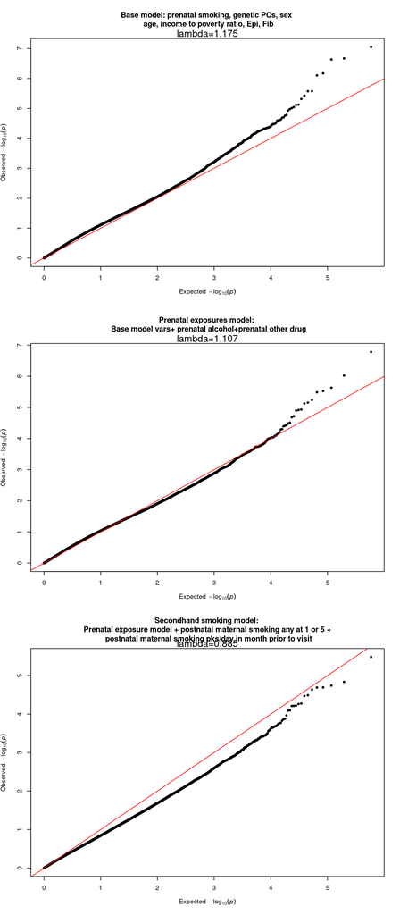

```r
par(mfrow=c(3, 1), mar=c(5.1, 4.1, 5.1, 2.1))
qq(teen.m1.ss.hits.annotated$P.Value, main='Base model: prenatal smoking, genetic PCs, sex \n age, income to poverty ratio, Epi, Fib')
mtext(paste0(expression(lambda), '=', round(l_t1, 3)), side=3)
qq(teen.m2.ss.hits.annotated$P.Value, main='Prenatal exposures model: \n Base model vars+ prenatal alcohol+prenatal other drug')
mtext(paste0(expression(lambda), '=', round(l_t2, 3)), side=3)
qq(teen.m3.ss.hits.annotated$P.Value, main='Secondhand smoking model: \n Prenatal exposure model + postnatal maternal smoking any at 1 or 5 + \n postnatal maternal smoking pks/day in month prior to visit')
mtext(paste0(expression(lambda), '=', round(l_t3, 3)), side=3)
```

## 3.2 Beta vs Beta plots within Age 15 models

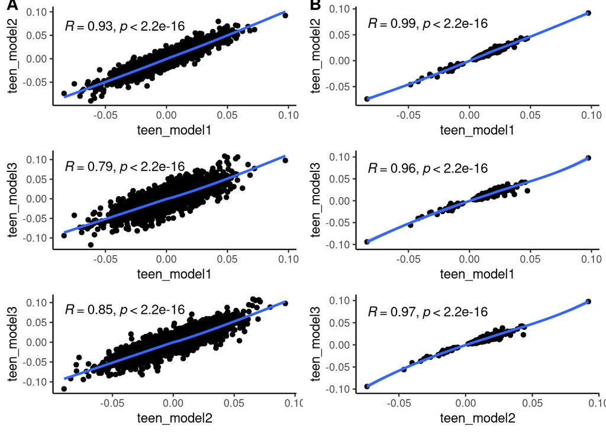

Correlation between effect estimates from the three different epigenome wide linear models in teens for A) all CpGs and B) significant CpGs only

```r
teen_models<-list('teen_model1'=teen.m1.ss.hits.annotated, 'teen_model2'=teen.m2.ss.hits.annotated, 'teen_model3'=teen.m3.ss.hits.annotated)%>%lapply(., function(x) rownames_to_column(x, var='CpG'))%>%Map(cbind, ., ModelType=names(.))

beta_teen<-lapply(teen_models, function(x) x %>%dplyr::select(CpG, logFC, ModelType)%>%pivot_wider(id_cols = CpG, values_from=logFC, names_from=ModelType))%>%purrr::reduce(left_join, by='CpG')

sig_beta_m1_t<-teen_models[[1]]%>%filter(P.Value<10e-4)%>%pull(CpG)

a<-smooth_betas(beta_teen, teen_model1, teen_model2)
b<-smooth_betas(beta_teen, teen_model1, teen_model3)
c<-smooth_betas(beta_teen, teen_model2, teen_model3)

d<-smooth_betas(beta_teen%>%filter(CpG %in% sig_beta_m1_t), teen_model1, teen_model2)
e<-smooth_betas(beta_teen%>%filter(CpG %in% sig_beta_m1_t), teen_model1, teen_model3)
f<-smooth_betas(beta_teen%>%filter(CpG %in% sig_beta_m1_t), teen_model2, teen_model3)

all_beta<-plot_grid(a, b, c, ncol=1)
sig_beta<-plot_grid(d, e, f, ncol=1)
plot_grid(all_beta, sig_beta, ncol=2, labels=c('A', 'B'), vjust = 0.8)
```

## 3.3 Table of top hits in teen EWAS

### 3.3.1 Model 1

```r
teen.m1.ss.hits.annotated%>% dplyr::rename(Beta.Coefficient=logFC, Average.Methylation=AveExpr)%>%head(n=10)%>%kable()%>%kable_classic()%>%scroll_box(width='100%', height='400px')
```

|  | Beta.Coefficient | CI.L | CI.R | Average.Methylation | t | P.Value | adj.P.Val | B | chr | pos | island | gene | regulatory_feature |
| --- | --- | --- | --- | --- | --- | --- | --- | --- | --- | --- | --- | --- | --- |
| cg05549655 | 0.0214552 | 0.0136617 | 0.0292486 | 0.1875594 | 5.404896 | 1.0e-07 | 0.0226738 | 6.038844 | chr15 | 75019143 | Island | CYP1A1 | Unclassified_Cell_type_specific |
| cg21370924 | 0.0254120 | 0.0158877 | 0.0349363 | 0.4149275 | 5.238304 | 2.0e-07 | 0.0226738 | 5.185496 | chr3 | 141087313 | OpenSea | ZBTB38 |  |
| cg04180046 | 0.0352994 | 0.0220279 | 0.0485708 | 0.3545740 | 5.221955 | 2.0e-07 | 0.0226738 | 5.103082 | chr7 | 45002736 | Island | MYO1G | Gene_Associated_Cell_type_specific |
| cg08360599 | 0.0235952 | 0.0143555 | 0.0328350 | 0.4350861 | 5.013584 | 7.0e-07 | 0.0461869 | 4.073664 | chr3 | 141087261 | OpenSea | ZBTB38 |  |
| cg20417500 | 0.0128238 | 0.0077705 | 0.0178771 | 0.2029291 | 4.982234 | 8.0e-07 | 0.0461869 | 3.922160 | chr5 | 73109241 | OpenSea | RGNEF |  |
| cg21475097 | 0.0181095 | 0.0105984 | 0.0256205 | 0.1848914 | 4.733603 | 2.7e-06 | 0.1117323 | 2.752117 | chr1 | 3164642 | Island | PRDM16;PRDM16 |  |
| cg01655356 | 0.0230955 | 0.0135144 | 0.0326765 | 0.1520606 | 4.732599 | 2.7e-06 | 0.1117323 | 2.747508 | chr11 | 70672841 | Island | SHANK2 |  |
| cg06039161 | 0.0191104 | 0.0110622 | 0.0271586 | 0.1368963 | 4.661799 | 3.7e-06 | 0.1368188 | 2.424672 | chr11 | 70672835 | Island | SHANK2 |  |
| cg22670819 | 0.0200584 | 0.0115096 | 0.0286072 | 0.3870814 | 4.606540 | 4.8e-06 | 0.1576131 | 2.175877 | chr6 | 31913759 | OpenSea | CFB;CFB |  |
| cg05697249 | 0.0153647 | 0.0086791 | 0.0220502 | 0.4904441 | 4.512041 | 7.5e-06 | 0.2035660 | 1.756906 | chr11 | 111789693 | OpenSea | C11orf52;C11orf52 |  |

### 3.3.2 Model 2

```r
teen.m2.ss.hits.annotated%>% dplyr::rename(Beta.Coefficient=logFC, Average.Methylation=AveExpr)%>%head(n=10)%>%kable()%>%kable_classic()%>%scroll_box(width='100%', height='400px')
```

|  | Beta.Coefficient | CI.L | CI.R | Average.Methylation | t | P.Value | adj.P.Val | B | chr | pos | island | gene | regulatory_feature |
| --- | --- | --- | --- | --- | --- | --- | --- | --- | --- | --- | --- | --- | --- |
| cg21370924 | 0.0278922 | 0.0175354 | 0.0382490 | 0.4149275 | 5.287407 | 2.00e-07 | 0.0483402 | 5.516052 | chr3 | 141087313 | OpenSea | ZBTB38 |  |
| cg08360599 | 0.0253231 | 0.0152706 | 0.0353757 | 0.4350861 | 4.945726 | 9.00e-07 | 0.1385708 | 3.828807 | chr3 | 141087261 | OpenSea | ZBTB38 |  |
| cg05549655 | 0.0205548 | 0.0120791 | 0.0290304 | 0.1875594 | 4.761319 | 2.30e-06 | 0.1914523 | 2.961901 | chr15 | 75019143 | Island | CYP1A1 | Unclassified_Cell_type_specific |
| cg26717563 | 0.0280304 | 0.0163466 | 0.0397141 | 0.8412181 | 4.710144 | 3.00e-06 | 0.1914523 | 2.726799 | chr19 | 3006111 | N_Shore | TLE2;TLE2;TLE2 |  |
| cg03940153 | 0.0216304 | 0.0125761 | 0.0306847 | 0.0853013 | 4.690249 | 3.30e-06 | 0.1914523 | 2.636046 | chr2 | 130940427 | Island | SMPD4;SMPD4;SMPD4;SMPD4;SMPD4;SMPD4;FAM128B;SMPD4 |  |
| cg04180046 | 0.0335854 | 0.0191552 | 0.0480155 | 0.3545740 | 4.569479 | 5.80e-06 | 0.2731722 | 2.092892 | chr7 | 45002736 | Island | MYO1G | Gene_Associated_Cell_type_specific |
| cg09695430 | 0.0188323 | 0.0106659 | 0.0269987 | 0.3901755 | 4.527499 | 7.00e-06 | 0.2731722 | 1.907218 | chr11 | 32447944 | N_Shore | WT1;WT1;WT1;WT1 |  |
| cg21475097 | 0.0187958 | 0.0106194 | 0.0269722 | 0.1848914 | 4.513223 | 7.50e-06 | 0.2731722 | 1.844446 | chr1 | 3164642 | Island | PRDM16;PRDM16 |  |
| cg01261086 | -0.0201913 | -0.0291719 | -0.0112107 | 0.9053433 | -4.414135 | 1.17e-05 | 0.3353264 | 1.413913 | chr16 | 75508622 | N_Shelf | CHST6 |  |
| cg12148979 | 0.0221075 | 0.0122575 | 0.0319574 | 0.0873702 | 4.406499 | 1.21e-05 | 0.3353264 | 1.381112 | chr2 | 132249369 | Island | FAM128A;LOC150776 |  |

### 3.3.3 Model 3

```r
teen.m3.ss.hits.annotated%>% dplyr::rename(Beta.Coefficient=logFC, Average.Methylation=AveExpr)%>%head(n=10)%>%kable()%>%kable_classic()%>%scroll_box(width='100%', height='400px')
```

|  | Beta.Coefficient | CI.L | CI.R | Average.Methylation | t | P.Value | adj.P.Val | B | chr | pos | island | gene | regulatory_feature |
| --- | --- | --- | --- | --- | --- | --- | --- | --- | --- | --- | --- | --- | --- |
| cg21370924 | 0.0291136 | 0.0169252 | 0.0413020 | 0.4149275 | 4.689646 | 3.30e-06 | 0.9607254 | 2.7920717 | chr3 | 141087313 | OpenSea | ZBTB38 |  |
| cg09653605 | 0.0117009 | 0.0064376 | 0.0169642 | 0.0337192 | 4.364689 | 1.46e-05 | 0.9999530 | 1.3618049 | chr16 | 57769555 | N_Shore | KATNB1 | Promoter_Associated |
| cg09973791 | -0.0082242 | -0.0119662 | -0.0044823 | 0.9747110 | -4.315035 | 1.82e-05 | 0.9999530 | 1.1518121 | chr15 | 28015719 | Island | OCA2 |  |
| cg09695430 | 0.0209844 | 0.0113808 | 0.0305880 | 0.3901755 | 4.289956 | 2.04e-05 | 0.9999530 | 1.0466185 | chr11 | 32447944 | N_Shore | WT1;WT1;WT1;WT1 |  |
| cg03940153 | 0.0231618 | 0.0125587 | 0.0337648 | 0.0853013 | 4.288757 | 2.05e-05 | 0.9999530 | 1.0416038 | chr2 | 130940427 | Island | SMPD4;SMPD4;SMPD4;SMPD4;SMPD4;SMPD4;FAM128B;SMPD4 |  |
| cg01261086 | -0.0229376 | -0.0335085 | -0.0123667 | 0.9053433 | -4.260172 | 2.32e-05 | 0.9999530 | 0.9224462 | chr16 | 75508622 | N_Shelf | CHST6 |  |
| cg02164462 | 0.0088045 | 0.0046715 | 0.0129375 | 0.0627477 | 4.182468 | 3.25e-05 | 0.9999530 | 0.6023593 | chr16 | 57769538 | N_Shore | KATNB1 | Promoter_Associated |
| cg24882168 | 0.0164908 | 0.0087298 | 0.0242517 | 0.8530308 | 4.171731 | 3.40e-05 | 0.9999530 | 0.5585716 | chrX | 123467232 | S_Shore |  |  |
| cg08360599 | 0.0244494 | 0.0126428 | 0.0362560 | 0.4350861 | 4.065683 | 5.33e-05 | 0.9999530 | 0.1318406 | chr3 | 141087261 | OpenSea | ZBTB38 |  |
| cg26717563 | 0.0284512 | 0.0146898 | 0.0422126 | 0.8412181 | 4.059080 | 5.47e-05 | 0.9999530 | 0.1056173 | chr19 | 3006111 | N_Shore | TLE2;TLE2;TLE2 |  |

# 4 Volcano plots for child and teen cross-sectional EWAS

```r
volc_child<-ggplot(child.m1.ss.hits.annotated%>%mutate(adjPval=ifelse(adj.P.Val<0.05, '<0.05', ifelse(adj.P.Val<0.2, '<0.2', '>0.2'))), aes(x=logFC, y=-log10(P.Value), color=adjPval))+geom_point()+scale_x_continuous('Beta (regression coefficient)')#+geom_hline(yintercept=-log10(0.05/dim(child.m2.ss.hits.annotated)[1]))
volc_teen<-ggplot(teen.m1.ss.hits.annotated%>%mutate(adjPval=ifelse(adj.P.Val<0.05, '<0.05', ifelse(adj.P.Val<0.2, '<0.2', '>0.2'))), aes(x=logFC, y=-log10(P.Value), color=adjPval))+geom_point()+scale_x_continuous('Beta (regression coefficient)')#+geom_hline(yintercept=-log10(0.05/dim(child.m2.ss.hits.annotated)[1]))
```

```r
png(file.path(outputdir, 'Volcano.png'), width=1300, height=800)
plot_grid(volc_child+theme_classic()+theme(text=element_text(size=16)), volc_teen+theme_classic()+theme(text=element_text(size=16)), ncol=2, labels=c('A Child', 'B Teen'), vjust = 0.8, label_size = 18)
dev.off()
```

# 5 Compare top hits in child and teen EWAS, and to other studies

```r
AllModels<-c(child_models, teen_models)

AllModelsdf<-AllModels %>% bind_rows(.id='ModelType')%>%mutate('Model'=gsub('.*_', '', ModelType), 'Age'=gsub('_.*', '', ModelType))

AllModelsdf=AllModelsdf%>%group_by(Model, Age, ModelType)%>%nest()%>%mutate(TopCpGs=map(data, function(x) x %>%filter(P.Value<1e-3)%>%pull(CpG)))%>%mutate(ModelType=case_when(ModelType=='child_model1'~'Age 9: Model 1', ModelType=='child_model2'~'Age 9: Model 2', ModelType=='child_model3'~'Age 9: Model 3', ModelType=='teen_model1'~'Age 15: Model 1', ModelType=='teen_model2'~'Age 15: Model 2', ModelType=='teen_model3'~'Age 15: Model 3'))%>%mutate(ModelType=factor(ModelType, levels=c('Age 9: Model 1', 'Age 9: Model 2', 'Age 9: Model 3', 'Age 15: Model 1', 'Age 15: Model 2', 'Age 15: Model 3')))
```

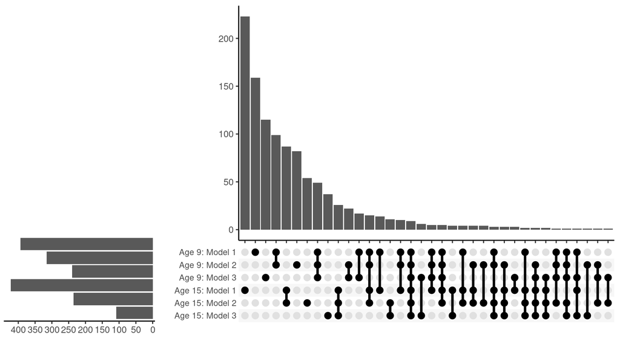

```r
a<-AllModelsdf %>% unnest(TopCpGs)%>%ungroup()%>%dplyr::select(ModelType, TopCpGs)%>%group_by(TopCpGs)%>%summarise(TypeList=list(ModelType))%>%ggplot(aes(x=TypeList))+geom_bar()+theme_classic2()+scale_x_upset(sets=c('Age 9: Model 1', 'Age 9: Model 2', 'Age 9: Model 3', 'Age 15: Model 1', 'Age 15: Model 2', 'Age 15: Model 3'), name='')+scale_y_continuous(name='')
b<-AllModelsdf %>%mutate(nCpGs=lengths(TopCpGs))%>%ggplot(aes(x=ModelType, y=-nCpGs))+geom_bar(position=position_dodge(), stat='identity')+coord_flip()+scale_y_continuous('',breaks=seq(0, -420, -50), labels=seq(0, 420, 50))+scale_x_discrete(limits=rev(levels(AllModelsdf$ModelType)))+theme_classic2()+theme(axis.text.y = element_blank(), axis.title.y = element_blank(), axis.ticks.y=element_blank(), axis.line.y = element_blank())
plot_grid(plot_grid(NULL, b + theme(plot.margin = unit(c(1, -5, -5, 1), "pt")), ncol = 1, rel_heights = c(2.15, 1)),a, nrow = 1, rel_widths = c(1, 3))
```

## 5.2 Beta estimates comparison of top hits from child and teen models

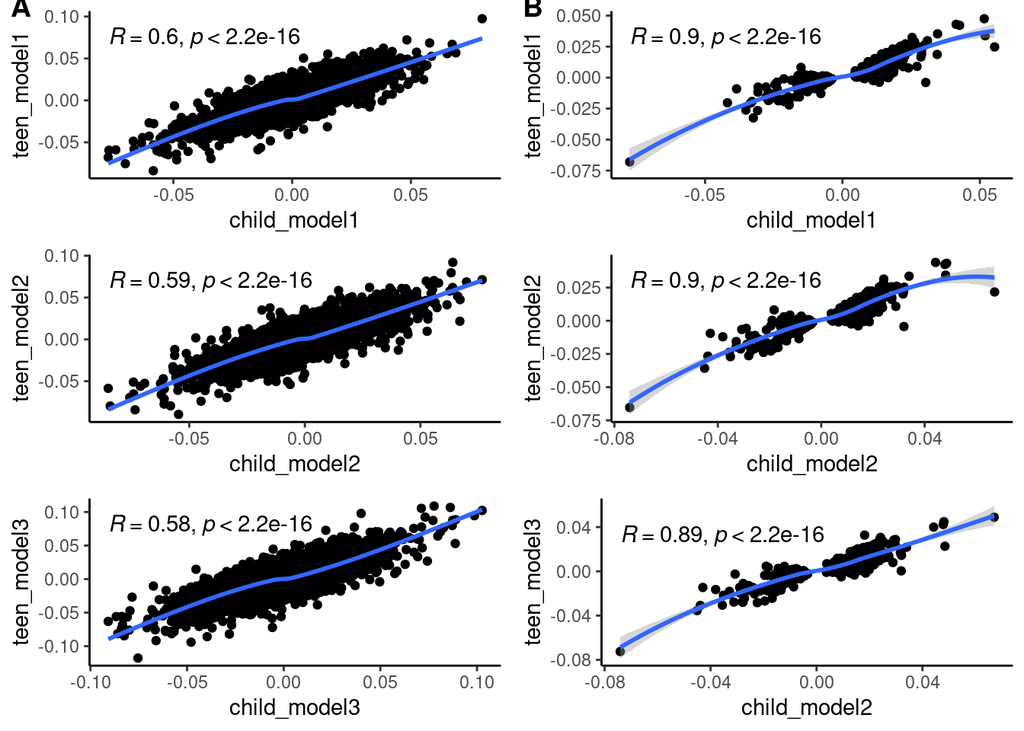

Correlation between effect estimates from the three different epigenome wide linear models in children vs in teens for A) all CpGs and B) significant CpGs only

```r
beta_all<-lapply(AllModels, function(x) x %>%dplyr::select(CpG, logFC, ModelType)%>%pivot_wider(id_cols = CpG, values_from=logFC, names_from=ModelType))%>%purrr::reduce(left_join, by='CpG')

sig_beta_m1<-child_models[[1]]%>%filter(P.Value<10e-4)%>%pull(CpG)


a<-smooth_betas(beta_all, child_model1, teen_model1)
b<-smooth_betas(beta_all, child_model2, teen_model2)
c<-smooth_betas(beta_all, child_model3, teen_model3)

d<-smooth_betas(beta_all%>%filter(CpG %in% sig_beta_m1), child_model1, teen_model1)
e<-smooth_betas(beta_all%>%filter(CpG %in% sig_beta_m1), child_model2, teen_model2)
f<-smooth_betas(beta_all%>%filter(CpG %in% sig_beta_m1), child_model2, teen_model3)

all_beta<-plot_grid(a, b, c, ncol=1)
sig_beta<-plot_grid(d, e, f, ncol=1)
all_beta_pres<-plot_grid(a, b, c, ncol=3)
sig_beta_pres<-plot_grid(d, e, f, ncol=3)
plot_grid(all_beta, sig_beta, ncol=2, labels=c('A', 'B'), vjust = 0.8)
```

```r
png(file.path(outputdir, 'BetaChildvsTeen.png'), width=1300, height=800)
plot_grid(all_beta_pres+theme(text=element_text(size=16)), sig_beta_pres+theme(text=element_text(size=16)), ncol=1, labels=c('A', 'B'), vjust = 0.8)
dev.off()
```

## 5.3 Similar top hits as Wicklund et al. 2019 and Joubert et al. 2016

```r
sigCpGs<-AllModelsdf%>%filter(Model=='model1')%>%mutate(data=map(data, function(x) x %>%filter(adj.P.Val<0.2)), SigCpG=map(data, function(x) x%>%pull(CpG)))%>%unnest(SigCpG)%>%pull(SigCpG) %>%unique()

betaqc<-readRDS(file=paste0(data.dir, 'CreatedData/', 'betaTrim.Rds'))
mybetaqc<-betaqc[sigCpGs%>%unique(), ]
#allgaps<-gaphunter(betaqc) #terminates r studio session (memory)
mygaps<-gaphunter(mybetaqc)
```

```
## [gaphunter] Using 27 probes and 1,739 samples.
```

```
## [gaphunter] Searching for gap signals.
```

```
## [gaphunter] Found 7 gap signals.
```

```
## [gaphunter] Filtering out gap signals driven by outliers.
```

```
## [gaphunter] Removed 2 gap signals driven by outliers from results.
```

```r
myBeta<-as.data.frame(t(mybetaqc))
myBeta$MethID =row.names(myBeta)
modeldata2<-left_join(modeldata%>%dplyr::select(-contains('cg')), myBeta)
```

```r
boxplotcpg<-modeldata2 %>% pivot_longer(cols=contains('cg'), names_to='CpG', values_to='Methylation')
notgap_samplecpg<-boxplotcpg%>%filter(!(CpG %in% row.names(mygaps$proberesults)))%>%pull(CpG)%>%unique()%>%head(n=4)

gap_plots<- ggplot(boxplotcpg%>%filter(CpG %in% row.names(mygaps$proberesults)), aes(x=childteen, y=Methylation, color=smkPreg_binary))+geom_jitter(position=position_dodge2(width=0.9), alpha=0.5)+geom_boxplot(alpha=0.8)+facet_wrap(~CpG)+theme(text=element_text(size=16))+scale_color_discrete(name='Prenatal smoke exposure?')+scale_x_discrete('', labels=c('Age 9', 'Age 15'))+theme_classic()+theme(legend.position='bottom')
not_gaps_plots<-ggplot(boxplotcpg%>%filter(!(CpG %in% row.names(mygaps$proberesults))), aes(x=childteen, y=Methylation, color=smkPreg_binary))+geom_boxplot()+facet_wrap(~CpG)+stat_compare_means(label='p.signif', label.y=0.9)+theme(text=element_text(size=16))+scale_color_discrete(name='Prenatal smoke exposure?')+theme(legend.position='bottom')+scale_x_discrete('', labels=c('Age 9', 'Age 15'))
not_gaps_sample<-ggplot(boxplotcpg%>%filter(CpG %in% notgap_samplecpg), aes(x=childteen, y=Methylation, color=smkPreg_binary))+geom_jitter(position=position_dodge2(width=0.9), alpha=0.5)+geom_boxplot(alpha=0.8)+facet_wrap(~CpG)+stat_compare_means(label='p.signif', label.y=0.9)+theme(text=element_text(size=16))+scale_color_discrete(name='Prenatal smoke exposure?')+scale_x_discrete('', labels=c('Age 9', 'Age 15'))+theme_classic()+theme(legend.position='bottom')
```

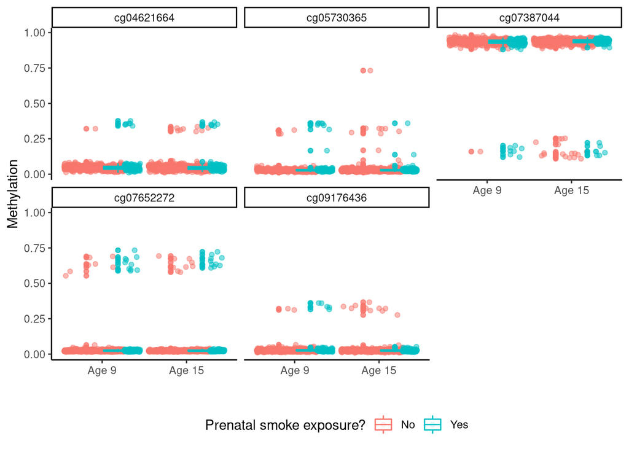

```r
gap_plots
```

```r
png(file.path(outputdir, 'GapPlots.png'), width=800, height=800)
gap_plots+theme(text=element_text(size=16))
dev.off()
```

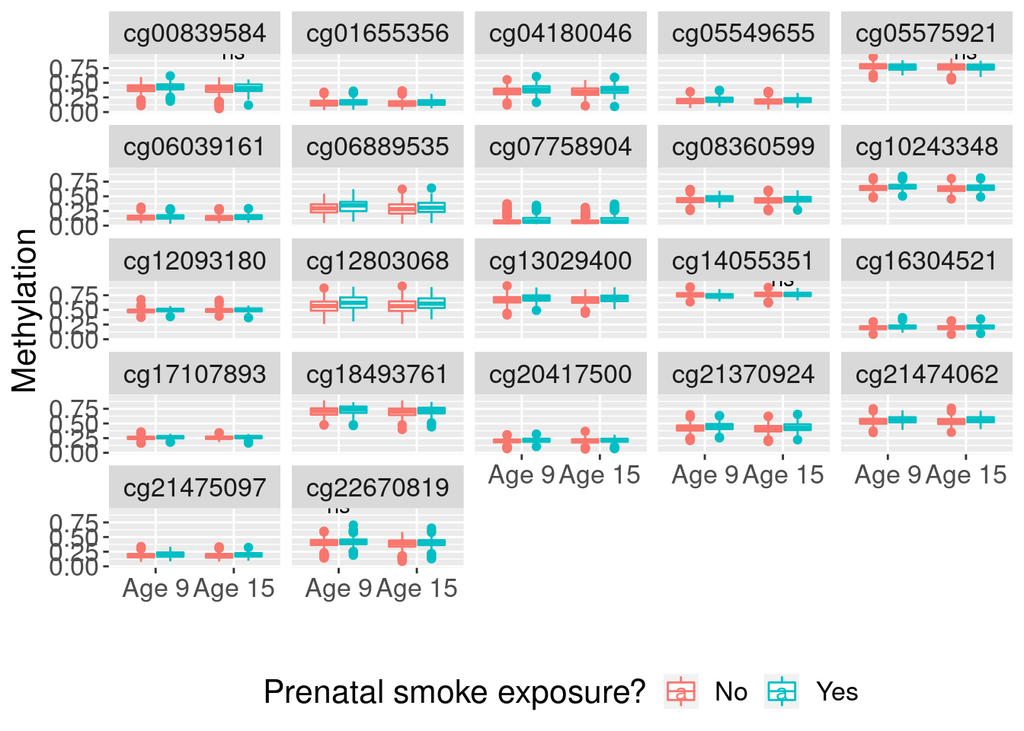

```r
not_gaps_plots
```

```r
png(file.path(outputdir, 'NotGapPlotsSample.png'), width=800, height=800)
not_gaps_sample+theme(text=element_text(size=16))
dev.off()
```

```r
#read in top CpGs from Table One of Wicklund et al 2019
topCPGs<-read.csv(paste0(data.dir, "TopCpGsWiklundEtAl2019.csv"))
topCPGs<-topCPGs %>% mutate(estimate=as.numeric(gsub("−\\s", "-", gsub(" .*", "", β..SE.))), std.error=as.numeric(sub("\\).*", "", sub(".*\\(", "", β..SE.))), p.value=P.value, source="Wiklund et al. 2019", conf.low=(estimate-1.96*std.error), conf.high=(estimate+1.96*std.error), set ='')%>%dplyr::select(CpG, Chr, Position, Gene, estimate, std.error, p.value, conf.low, conf.high, source, set)

#read in Joubert meta top cpgs
#read in cpgs from PMC4833289
cpgs<-read.csv(paste0(data.dir, 'PMC4833289_SuppFile2CpGs.csv'), stringsAsFactors = F, header=F, skip=2)
#make headers
header1<-scan(paste0(data.dir, 'PMC4833289_SuppFile2CpGs.csv'), nlines=1, what=character(), sep=',')
header1[7:26]<-c(rep("SSnewborn", 5), rep("SSnewbornCT", 5), rep("SSolder", 5), rep("anynewborn", 5))
header2<-paste(header1, scan(paste0(data.dir, 'PMC4833289_SuppFile2CpGs.csv'), nlines=1, skip=1, what=character(), sep=','), sep='_')
names(cpgs)<-header2

#four meta-EWASes: SS_newborn (sustained smoking in newborns); SS_newbornCT (sustained smoking in newborns controlling for cell type) SS_older (sustained smoking in older children); any_newborn (any smoking in newborns)
#pivot_longer to get single column of coefs and a column for the analysis type
#and group into a list by analysis type
cpgs<-cpgs %>% pivot_longer(cols = c(matches("_Coef|_SE|_P|_FDR|_Direction")), names_to = c("set", ".value"), names_pattern="(.+)_(.+)")%>%rename_with(~gsub('_', '', .x))%>%mutate(Gene=`Mapped Gene`, estimate=Coef, conf.low=estimate-1.96*SE, conf.high=estimate+1.96*SE, source='Joubert et al. 2016', std.error=SE, p.value=P, Chr=CHR) %>%mutate(source=paste0(source, ': ', set))%>%dplyr::select(CpG, Chr, Position, Gene, estimate, std.error, p.value, conf.low, conf.high, source, set)%>%filter(set %in% c('SSolder', 'SSnewbornCT'))


myCPGs<-AllModelsdf %>%filter(Model=='model1')%>%mutate(data=map(data, function(x) x %>%filter(CpG %in% sigCpGs)))%>%unnest(cols=c(data))%>%mutate(Joubertetal=ifelse(CpG %in% cpgs$CpG, 'in Joubert et al. 2016', 'Not in Joubert et al. 2016'), Wicklundetal=ifelse(CpG %in% topCPGs$CpG, 'in Wicklund et al. 2019', 'Not in Wicklund et al. 2019'))%>%mutate(Gene=gene, estimate=logFC, conf.low=CI.L, conf.high=CI.R, source=paste0('Fragile Families:', Age), std.error='NA', p.value=P.Value, Chr=chr, set='Model1', Position=pos)

#myCPGs<-child.m1.ss.hits.annotated %>% filter(adj.P.Val<0.2)%>%mutate(CpG=row.names(.))%>%mutate(Joubertetal=ifelse(CpG %in% cpgs$CpG, 'in Joubert et al. 2016', 'Not in Joubert et al. 2016'), Wicklundetal=ifelse(CpG %in% topCPGs$CpG, 'in Wicklund et al. 2019', 'Not in Wicklund et al. 2019'))%>%mutate(Gene=gene, estimate=logFC, conf.low=CI.L, conf.high=CI.R, source='Fragile Familes Age 9', std.error='NA', p.value=P.Value, Chr=chr, set='Model1', Position=pos)


cpg_overlap=myCPGs%>%filter(Joubertetal=='in Joubert et al. 2016' | Wicklundetal=='in Wicklund et al. 2019')%>%pull(CpG)%>%unique()

myCPGs2<-myCPGs %>%ungroup()%>%dplyr::select(CpG, Chr, Position, Gene, estimate, std.error, p.value, conf.low, conf.high, source, set)%>%mutate(CpG=ifelse(CpG %in% row.names(mygaps$proberesults), paste0(CpG, '*'), CpG))

cpg_all<-rbind(myCPGs2, cpgs, topCPGs)%>% filter(CpG%in% cpg_overlap)
cpgs_new<-myCPGs2%>%filter(!(CpG %in% cpg_overlap))

#geom blank to give good axes limits
blank_data <- cpg_all %>% filter(CpG%in% cpg_overlap)%>%dplyr::select(Gene, CpG, estimate, std.error)%>%group_by(Gene)%>%mutate(min=min(estimate), max=max(as.numeric(std.error), na.rm=T))%>%dplyr::select(-estimate, -std.error)%>%unique()%>%mutate(estimate=min*-1+max, conf.high=estimate, conf.low=estimate)%>%dplyr::select(-max, -min)%>%arrange(Gene)%>%mutate(source='Wiklund et al. 2019')
blank_data2 <- cpgs_new %>%dplyr::select(Gene, CpG, estimate, std.error)%>%group_by(Gene)%>%mutate(min=min(estimate))%>%dplyr::select(-estimate, -std.error)%>%unique()%>%mutate(estimate=min*-1+0.005, conf.high=estimate, conf.low=estimate)%>%dplyr::select(-min)%>%arrange(Gene)%>%mutate(source='Fragile Families:child')

plot_sharedCpG<-ggplot(cpg_all, aes(x=estimate, xmin=conf.low, xmax=conf.high, color=source, y=CpG))+geom_point(position=position_dodge(width=1))+geom_errorbarh(height=0.1, position=position_dodge(width=1))+scale_x_continuous()+geom_vline(xintercept=0, color='red', linetype="dashed", alpha=0.5)+facet_wrap(.~Gene, scales='free', ncol=2)+theme_classic()+theme(legend.position = 'bottom')+guides(color=guide_legend(nrow=2,byrow=TRUE))+geom_blank(data = blank_data, aes(x = estimate))

plot_newCpG<-ggplot(cpgs_new, aes(x=estimate, xmin=conf.low, xmax=conf.high, color=source, y=CpG))+geom_point(position=position_dodge(width=1))+geom_errorbarh(height=0.1, position=position_dodge(width=1))+scale_x_continuous()+geom_vline(xintercept=0, color='red', linetype="dashed", alpha=0.5)+facet_wrap(.~Gene, scales='free')+theme_classic()+theme(legend.position = 'bottom')+guides(color=guide_legend(nrow=2,byrow=TRUE))+geom_blank(data = blank_data2, aes(x = estimate))

cut_cpgs<-c(paste0(row.names(mygaps$proberesults), '*'), 'cg14055351')
plot_newCpG_cut<-ggplot(cpgs_new%>%filter(!(CpG%in%cut_cpgs)), aes(x=estimate, xmin=conf.low, xmax=conf.high, color=source, y=CpG))+geom_point(position=position_dodge(width=1))+geom_errorbarh(height=0.1, position=position_dodge(width=1))+scale_x_continuous()+geom_vline(xintercept=0, color='red', linetype="dashed", alpha=0.5)+facet_wrap(.~Gene, scales='free')+theme_classic()+theme(legend.position = 'bottom')+guides(color=guide_legend(nrow=2,byrow=TRUE))+geom_blank(data = blank_data2%>%filter(!(CpG %in%cut_cpgs)), aes(x = estimate))
```

Filtering to only CpGs that had an adjusted p-value of <0.2 in either the base child & teen models ($m_{CpG_{p_{BH}<0.2}}=$ 27), and then to only CpGs that overlapped with results from either Wicklund et al. 2019 or Joubert et al. 2016 ($m_{CpG_{overlap}}=$ 9 ), plot the estimates with error bars and compare.

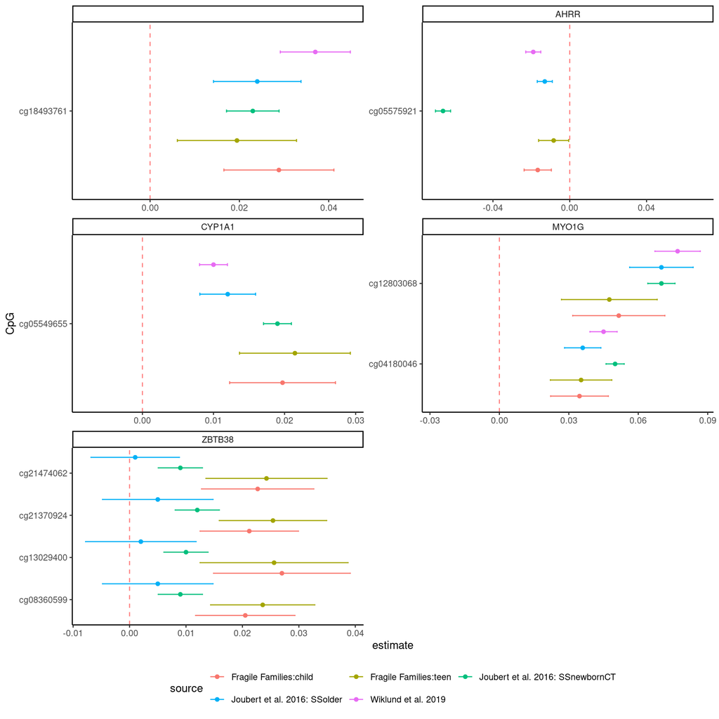

```r
plot_sharedCpG
```

```r
png(file.path(outputdir, 'SharedCpG.png'), width=1000, height=800)
plot_sharedCpG+theme(text=element_text(size=18))
dev.off()
```

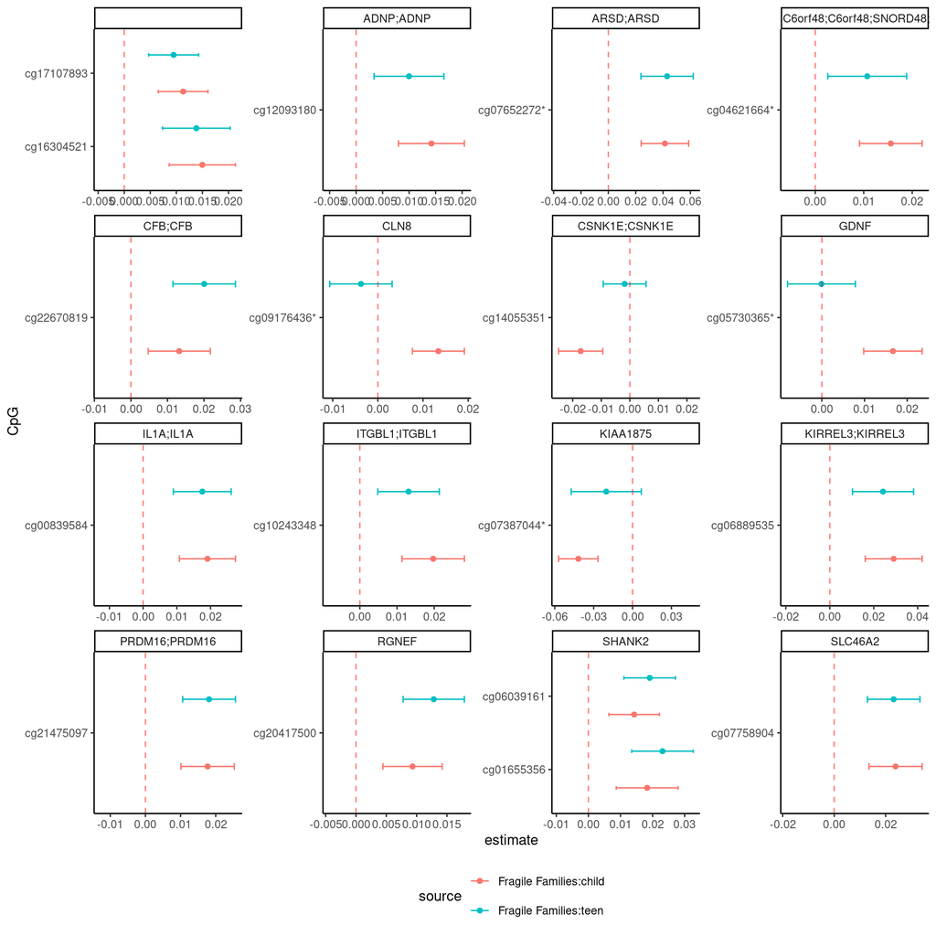

```r
plot_newCpG
```

```r
png(file.path(outputdir, 'NewCpG.png'), width=1300, height=1000)
plot_newCpG+theme(text=element_text(size=18))
dev.off()
```

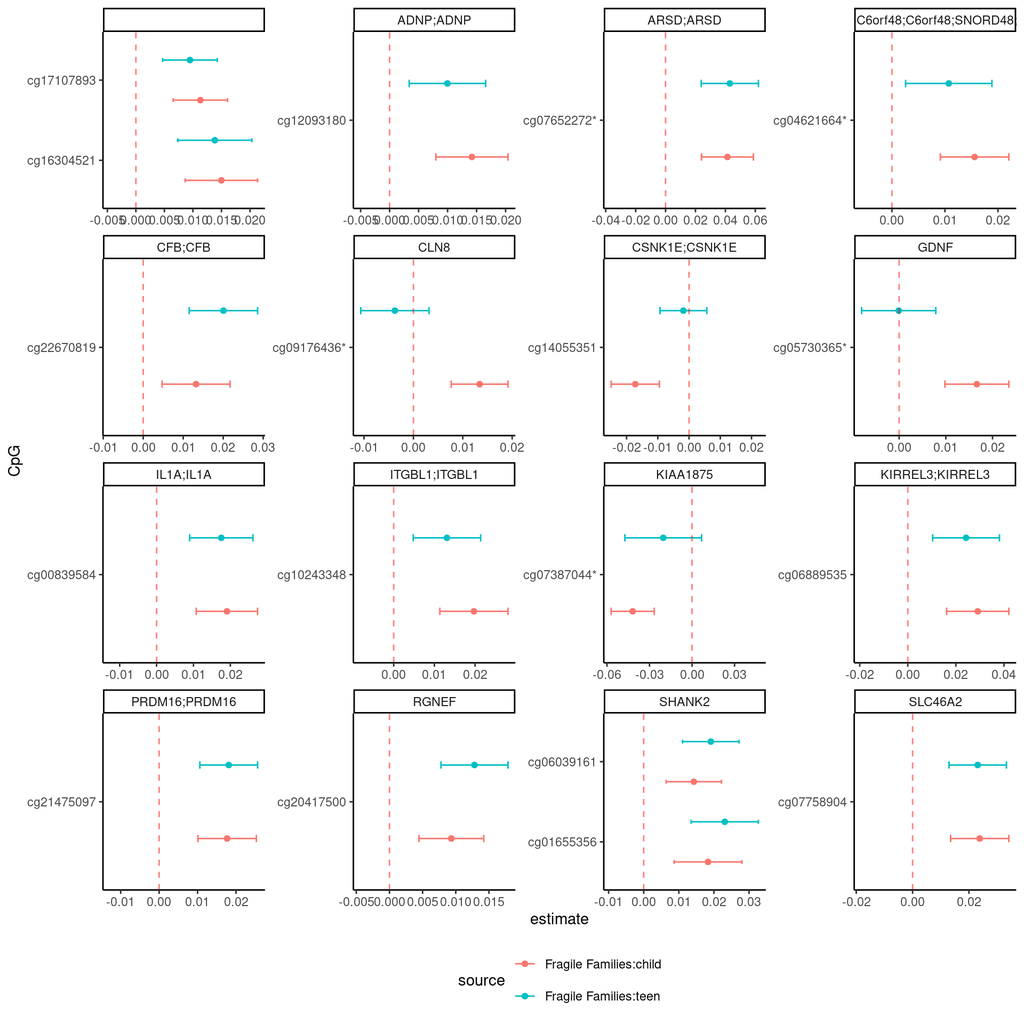

```r
plot_newCpG
```

```r
png(file.path(outputdir, 'NewCpGCut.png'), width=1300, height=1000)
plot_newCpG_cut+theme(text=element_text(size=18))
dev.off()
```

# 6 Longitudinal EWAS

```r
#load in betaqc matrix (trimmed)
#betaqc<-readRDS(file=paste0(data.dir, 'CreatedData/', 'betaTrim.Rds'))
#filter betaqc to modeldata samples only
beta_all <-betaqc[, colnames(betaqc) %in% modeldata$MethID]#; rm(betaqc)
#make sure that the order of the samples matches in the metadata matrix and the beta matrix are ordered the same
modeldata<-modeldata[match(colnames(beta_all), modeldata$MethID), ]
#checks
if(dim(beta_all)[2]!=dim(modeldata)[1]){print('STOP: Sample #s do not match')}
if(identical(colnames(beta_all), modeldata$MethID)==FALSE){print('STOP: Sample names do not match')}
```

```r
mod1=model.matrix(~factor(modeldata$smkPreg_binary)+modeldata$global_PC1+modeldata$global_PC2+factor(modeldata$cm1bsex)+modeldata$cm1inpov+modeldata$ChildAgeComposite+modeldata$Epi+modeldata$IC+factor(modeldata$smkPreg_binary)*modeldata$ChildAgeComposite)

mod2=model.matrix(~factor(modeldata$smkPreg_binary)+modeldata$global_PC1+modeldata$global_PC2+factor(modeldata$cm1bsex)+modeldata$cm1inpov+modeldata$ChildAgeComposite+modeldata$Epi+modeldata$IC+factor(modeldata$m1g2_YesNoPreg)+factor(modeldata$m1g3_YesNoPreg)+factor(modeldata$smkPreg_binary)*modeldata$ChildAgeComposite)

mod3=model.matrix(~factor(modeldata$smkPreg_binary)+modeldata$global_PC1+modeldata$global_PC2+factor(modeldata$cm1bsex)+modeldata$cm1inpov+modeldata$ChildAgeComposite+modeldata$Epi+modeldata$IC+factor(modeldata$m1g2_YesNoPreg)+factor(modeldata$m1g3_YesNoPreg)+factor(modeldata$PostnatalMaternalSmokingAny)+factor(modeldata$SmkAtVisitPastmonth)+factor(modeldata$smkPreg_binary)*modeldata$ChildAgeComposite)

modellist=list(mod1, mod2, mod3)
modelnames=c('limmaModel1Long.Rda', 'limmaModel2Long.Rda', 'limmaModel3Long.Rda')
tophitnames_smk=c('LongModel1TopHits_smk.Rda', 'LongTeenModel2TopHits_smk.Rda', 'LongModel3TopHits_smk.Rda')
tophitnames_age=c('LongModel1TopHits_age.Rda', 'LongTeenModel2TopHits_age.Rda', 'LongModel3TopHits_age.Rda')
tophitnames_int=c('LongModel1TopHits_int.Rda', 'LongTeenModel2TopHits_int.Rda', 'LongModel3TopHits_int.Rda')
tophitnames=cbind(tophitnames_smk, tophitnames_age, tophitnames_int)
coef=c(2, 7, 10)
```

```r
#concern: For this function (duplicateCorrelation) to return statistically useful results, there must be at least two more arrays than the number of coefficients to be estimated, i.e., two more than the column rank of design.(from: https://rdrr.io/bioc/limma/man/dupcor.html)... because the design matrix is pretty large (many coefficients) is this a problem for us?
#this is also taking forever, I think I should run the duplicateCorrelation on a subset of rows (see: https://support.bioconductor.org/p/117817/), see if it's normally distributed and then just use the median for everyone
  print(paste('Fitting correlation structure for Model', i))
  corfit<-duplicateCorrelation(beta_all, design=modellist[[i]], block=modeldata$id)


for(i in 1:length(modellist)){
  print(paste('Fitting correlation structure for Model', i))
  corfit<-duplicateCorrelation(beta_all, design=modellist[[i]], block=modeldata$id)
  print(paste('Running Model', i))
  out=lmFit(beta_all, modellist[[i]], block=modeldata$id, correlation=corfit$consensus)
  out=eBayes(out)
  saveRDS(out, file=file.path(limma.out.dir, modelnames[i]))
  for(j in 1:3){
    print(paste('Annotating top hits from model', i, 'coef', coef[j]))
    long.ss.hits<-topTable(out, coef=coef[j], number=nrow(beta_all), confint=T)
    long.ss.annotated.hits<-add_annotations(long.ss.hits)
    saveRDS(long.ss.annotated.hits, file=file.path(limma.out.dir, tophitnames[i, j]))
    rm(long.ss.hits, long.ss.annotated.hits)
  }
  rm(out)
}
```